# 4 結果と考察

# 5 結果と考察

## 5.1 結果

### Q1-1：賃金カーブ（年齢ごとの賃金の差）

表 5.1 に、年齢階級別の看護師と一般労働者（大卒・産業計）の月額賃金の差を示す。

表 5.1: 看護師と一般労働者の月額賃金の差（2025年）

| 年齢 | 一般労働者（円） | 看護師（円） | 賃金差（円） | 賃金比 |
| --- | --- | --- | --- | --- |
| 25〜29歳 | 332,700 | 351,900 | 19,200 | 1.06 |
| 35〜39歳 | 419,400 | 359,300 | -60,100 | 0.86 |
| 45〜49歳 | 486,700 | 387,000 | -99,700 | 0.80 |

25〜29歳では、看護師が一般労働者を19,200円上回る。35〜39歳では逆に60,100円下回り、45〜49歳では99,700円下回る。差は年齢とともに開いている（図 5.1）。

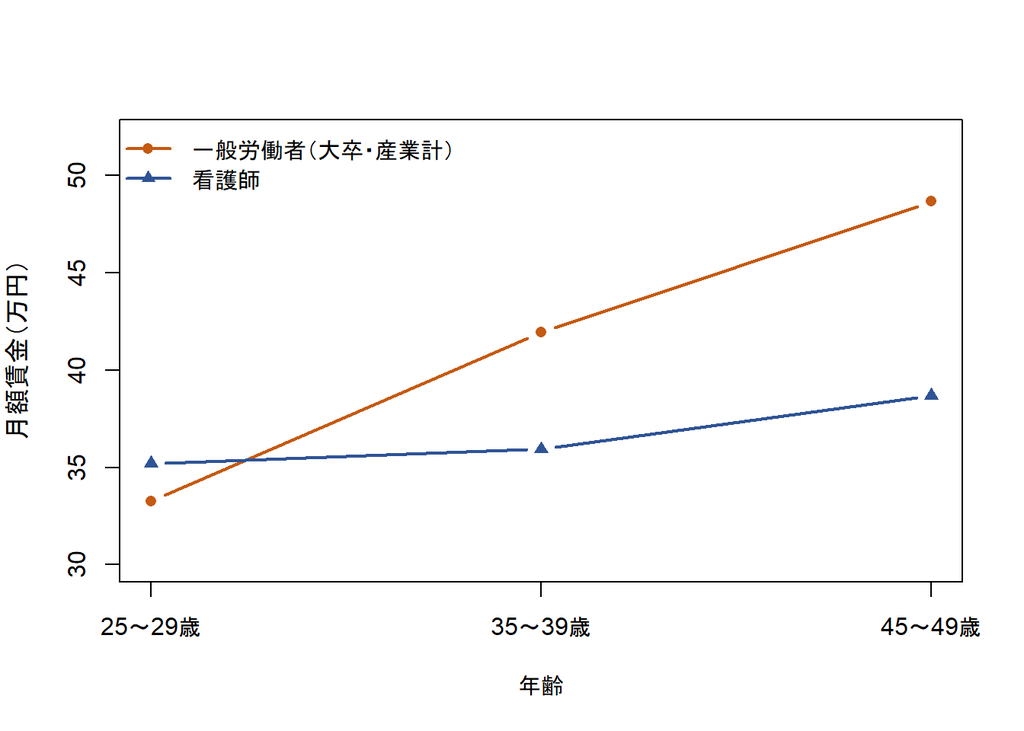

図 5.1: 年齢階級別の月額賃金：看護師と一般労働者（大卒・産業計）

25〜29歳から45〜49歳までの賃金の伸びは、一般労働者が46.3%、看護師が10.0%である。看護師の賃金カーブは、一般労働者に比べて大きく寝ている。

### Q1-2：賃上げ実施率

表 5.2 に、2026年度の賃上げ実施率と前年度との差を示す。

表 5.2: 賃上げ実施率（%）と前年度との差（ポイント）

| 区分 | 調査 | 2026年度 | 2025年度 | 前年度との差 |
| --- | --- | --- | --- | --- |
| 病院 | 日本看護協会 | 68.7 | 58.6 | 10.1 |
| 訪問看護事業所 | 日本看護協会 | 73.2 | 56.6 | 16.6 |
| 大企業 | 東京商工リサーチ | 93.8 | 92.6 | 1.2 |
| 中小企業 | 東京商工リサーチ | 82.3 | 80.9 | 1.4 |

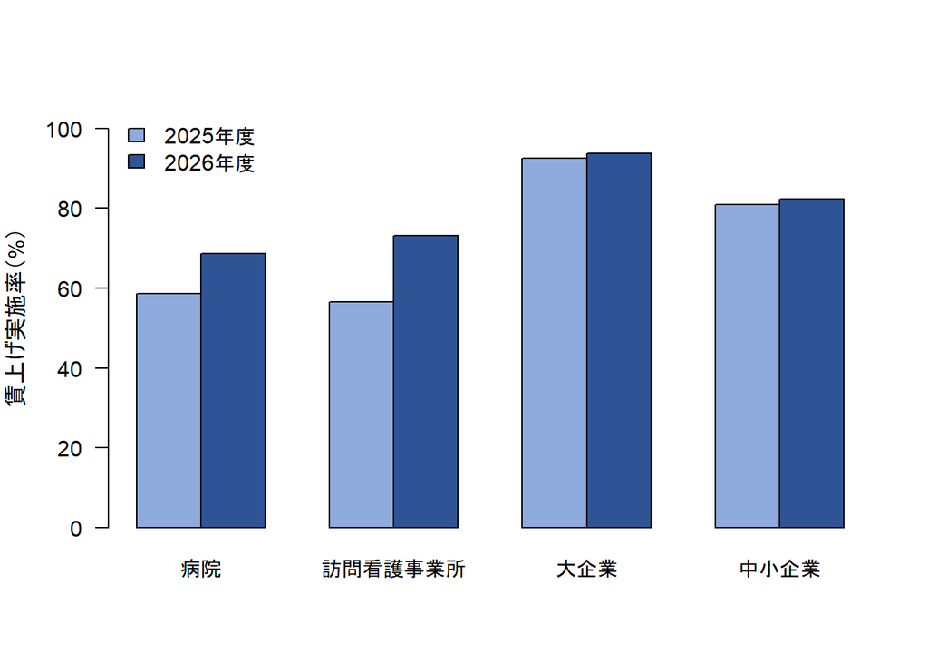

図 5.2: 賃上げ実施率の比較（2025年度と2026年度）

実施率の水準は、病院（68.7%）・訪問看護事業所（73.2%）が、大企業（93.8%）・中小企業（82.3%）より低い。一方、前年度からの上昇幅は、病院が10.1ポイント、訪問看護事業所が16.6ポイントで、民間企業（1.2・1.4ポイント）より大きい。実施の有無という点では、差は縮まりつつある。

### Q1-3：賃上げ率の大きさ

賃上げした施設の賃上げ率の分布を 図 5.3 に示す。

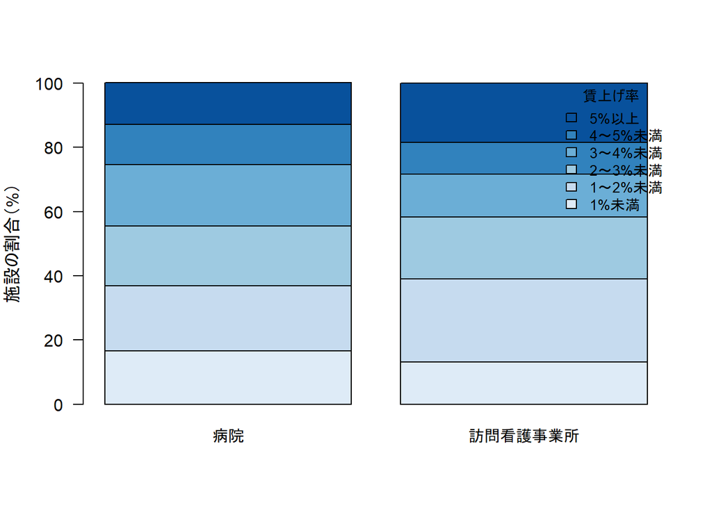

図 5.3: 賃上げした施設の賃上げ率の分布（%）

賃上げ率が2%未満の施設は、病院で36.9%、訪問看護事業所で39.0%である。3%以上の施設は、病院で44.6%、訪問看護事業所で41.7%である。

参考として、「5%以上」の賃上げをした割合は、病院が13.0%、訪問看護事業所が18.4%である。東京商工リサーチの調査では、大企業が41.4%、中小企業が42.6%である。ただし、民間の数値は割合の基数が確認できておらず、看護職員側は賃上げした施設に占める割合なので、直接の比較はできない。

### Q1-4：基本給の増え方

表 5.3: 2026年8月の基本給と前年同月からの増加（日本看護協会調査）

| 就業先 | 基本給（円） | 前年同月差（円） | 増加率（逆算、%） |
| --- | --- | --- | --- |
| 病院 | 274,754 | 7,261 | 2.7 |
| 訪問看護事業所 | 258,237 | 2,913 | 1.1 |
| 介護保険施設・事業所 | 251,707 | 1,279 | 0.5 |

病院勤務の看護職員の基本給は、前年同月から約2.7%増えている。訪問看護事業所は約1.1%、介護保険施設・事業所は約0.5%と、就業先によって増え方が違う。

## 5.2 考察

ここでは、結果の「なぜ」を先行研究と制度資料に照らして考える。以下は**仮説**であり、本研究のデータで検証したものではない。各項目に、根拠の種類を付ける。

### 1. 乖離はどこに現れているか（Q1への答え）

看護師の賃金は、20代では一般労働者を上回る。乖離の中心は、**30代以降に賃金が伸びないこと**である（図 5.1）。賃上げでは、実施率では差が縮まりつつあるが、賃上げ率の水準と、民間との差の指摘が残る。

### 2. 制度の要因：公定価格と、賃金改善を直接の目的としない仕組み

- **根拠あり：** 診療報酬は、個々の診療行為ごとに報酬が決まる公定価格である。診療報酬には看護職員の配置増に対する加算等はあるが、賃金改善を直接の目的とする仕組みはないとされている。
- **根拠あり：** 看護師の賃金は、診療報酬制度のもとで、総人件費の予算制約によって抑えられる場合と、平均在院日数や看護師比率で押し上げられる場合がある。
- **根拠あり：** 2026年度の賃上げの原資は、診療報酬・介護報酬等の評価や国の補助金によるものと整理されている。

つまり、病院が自らの判断で価格を上げて賃上げ原資を確保することは難しく、賃上げの大きさは制度設計に左右されやすい。

### 3. 賃金カーブが寝ている理由

- **根拠あり：** 日本看護協会は、横ばいの賃金カーブについて、施設の管理者に賃金モデルの提案などで対応していきたいとしている。経験を積んでも賃金が上がる仕組みが、施設に十分にないことを示唆する。
- **根拠あり：** 賃金が増えた理由の2番目は、病院・訪問看護事業所とも「時間外勤務や夜勤回数・オンコール対応回数の増加」である。賃金の増加が、基本給の上昇よりも労働量の増加に頼っている可能性がある。
- **仮説：** 20代で看護師の賃金が高いのは、夜勤などの手当が賃金に含まれるためかもしれない。統計の定義（手当の扱い）を確認する必要がある。

### 4. 他産業との差

- **根拠あり：** 日本看護協会は、賃上げ実施率・賃上げ率とも他産業には遠く及ばないと指摘している。
- **仮説：** 民間企業は、価格の設定や取引条件の見直しによって賃上げ原資を確保できるのに対し、診療報酬は価格が公定されているため、その余地が小さい。民間側の事情は本研究のデータにはなく、検証できていない。

### 5. 「医療費が増えているのに」という点について

**未検証：** 本研究は、医療費の増加と賃金原資の関係を直接には調べていない。医療費の総額が増えても、その増加が患者数や高齢化などの量の増加によるものであれば、診療報酬の単価や、1人の看護師に回る原資が同じように増えるとは限らない。この点は、診療報酬改定率、医療機関の収支（医療経済実態調査など）、人件費の割合のデータを重ねて検証する必要がある。

### 6. 乖離の帰結

**根拠あり：** 8割弱の看護職員が賃金に不満を抱いており、不満が強い人ほど、現在の勤務先で働き続ける意向や看護職員を続ける意向が低い傾向がある。賃金の問題は、人材の定着にも関わっている。